# Differential Expression of Flexwood data

Elena van Zalen

2022-04-08

# 1 Setup

- Libraries

```r
suppressPackageStartupMessages({
  library(data.table)
  library(DESeq2)
  library(dplyr)
  library(gplots)
  library(here)
  library(hyperSpec)
  library(magrittr)
  library(pheatmap)
  library(RColorBrewer)
  library(tidyverse)
  library(VennDiagram)
})
```

- Helper files

```r
suppressMessages({
  source(here("UPSCb-common/Rtoolbox/src/plotEnrichedTreemap.R"))
  source(here("UPSCb-common/src/R/featureSelection.R"))
  source(here("UPSCb-common/src/R/volcanoPlot.R"))
  source(here("UPSCb-common/src/R/gopher.R"))
})
```

- Graphics

```r
pal = brewer.pal(8, "Dark2")
hpal <- colorRampPalette(c("blue", "white", "red"))(100)
mar <- par("mar")
```

TODO remember to add a function to check for correlation between logFC and transcript length - check for the effective length * Functions 1. plot specific gene expression

```r
"line_plot" <- function(dds = dds, vst = vst, gene_id = gene_id){
  message(paste("Plotting",gene_id))
  sel <- grepl(gene_id,rownames(vst))
  stopifnot(sum(sel)==1)

  p <- ggplot(bind_cols(as.data.frame(colData(dds)),
                        data.frame(value=vst[sel,])),
              aes(x=MDay,y=value,col=MGenotype,group=MGenotype)) +
    geom_point() + geom_smooth() +
    scale_y_continuous(name="VST expression") +
    ggtitle(label=paste("Expression for: ",gene_id))

  suppressMessages(suppressWarnings(plot(p)))
  return(NULL)
}
```

2. extract the DE results. Default cutoffs are from Schurch *et al.*, RNA, 2016

```r
"extract_results" <- function(dds,vst,contrast,
                              padj=0.01,lfc=0.5,
                              plot=TRUE,verbose=TRUE,
                              export=TRUE,default_dir=here("data/analysis/DE"),
                              default_prefix="DE-",
                              annot = tibble(),
                              labels=dds$Name,
                              sample_sel=1:ncol(dds),
                              expression_cutoff=0,
                              debug=FALSE,filter=c("median",NULL),...){

  # get the filter
  if(!is.null(match.arg(filter))){
    filter <- rowMedians(counts(dds,normalized=TRUE))
    message("Using the median normalized counts as default, set filter=NULL to revert to using the mean")
  }

  # validation
  if(length(contrast)==1){
    res <- results(dds,name=contrast,filter = filter)
  } else {
    res <- results(dds,contrast=contrast,filter = filter)
  }

  stopifnot(length(sample_sel)==ncol(vst))

  if(plot){
    par(mar=c(5,5,5,5))
    volcanoPlot(res)
    par(mar=mar)
  }

  # a look at independent filtering
  if(plot){
    plot(metadata(res)$filterNumRej,
         type="b", ylab="number of rejections",
         xlab="quantiles of filter")
    lines(metadata(res)$lo.fit, col="red")
    abline(v=metadata(res)$filterTheta)
  }

  if(verbose){
    message(sprintf("The independent filtering cutoff is %s, removing %s of the data",
                    round(metadata(res)$filterThreshold,digits=5),
                    names(metadata(res)$filterThreshold)))

    max.theta <- metadata(res)$filterNumRej[which.max(metadata(res)$filterNumRej$numRej),"theta"]
    message(sprintf("The independent filtering maximises for %s %% of the data, corresponding to a base mean expression of %s (library-size normalised read)",
                    round(max.theta*100, digits=5),
                    round(quantile(counts(dds, normalized = TRUE), probs = max.theta), digits = 5)))
  }

  if(plot){
    qtl.exp=quantile(counts(dds,normalized=TRUE),probs=metadata(res)$filterNumRej$theta)
    dat <- data.frame(thetas=metadata(res)$filterNumRej$theta,
                      qtl.exp=qtl.exp,
                      number.degs=sapply(lapply(qtl.exp,function(qe){
                        res$padj <= padj & abs(res$log2FoldChange) >= lfc &
                          ! is.na(res$padj) & res$baseMean >= qe
                      }),sum))
    if(debug){
      plot(ggplot(dat,aes(x=thetas,y=qtl.exp)) +
             geom_line() + geom_point() +
             scale_x_continuous("quantiles of expression") +
             scale_y_continuous("base mean expression") +
             geom_hline(yintercept=expression_cutoff,
                        linetype="dotted",col="red"))

      p <- ggplot(dat,aes(x=thetas,y=qtl.exp)) +
        geom_line() + geom_point() +
        scale_x_continuous("quantiles of expression") +
        scale_y_log10("base mean expression") +
        geom_hline(yintercept=expression_cutoff,
                   linetype="dotted",col="red")
      suppressMessages(suppressWarnings(plot(p)))

      plot(ggplot(dat,aes(x=thetas,y=number.degs)) +
             geom_line() + geom_point() +
             geom_hline(yintercept=dat$number.degs[1],linetype="dashed") +
             scale_x_continuous("quantiles of expression") +
             scale_y_continuous("Number of DE genes"))

      plot(ggplot(dat,aes(x=thetas,y=number.degs[1] - number.degs),aes()) +
             geom_line() + geom_point() +
             scale_x_continuous("quantiles of expression") +
             scale_y_continuous("Cumulative number of DE genes"))

      plot(ggplot(data.frame(x=dat$thetas[-1],
                             y=diff(dat$number.degs[1] - dat$number.degs)),aes(x,y)) +
             geom_line() + geom_point() +
             scale_x_continuous("quantiles of expression") +
             scale_y_continuous("Number of DE genes per interval"))

      plot(ggplot(data.frame(x=dat$qtl.exp[-1],
                             y=diff(dat$number.degs[1] - dat$number.degs)),aes(x,y)) +
             geom_line() + geom_point() +
             scale_x_continuous("base mean of expression") +
             scale_y_continuous("Number of DE genes per interval"))

      p <- ggplot(data.frame(x=dat$qtl.exp[-1],
                             y=diff(dat$number.degs[1] - dat$number.degs)),aes(x,y)) +
        geom_line() + geom_point() +
        scale_x_log10("base mean of expression") +
        scale_y_continuous("Number of DE genes per interval") +
        geom_vline(xintercept=expression_cutoff,
                   linetype="dotted",col="red")
      suppressMessages(suppressWarnings(plot(p)))
    }
  }

  sel <- res$padj <= padj & abs(res$log2FoldChange) >= lfc & ! is.na(res$padj) &
    res$baseMean >= expression_cutoff

  if(verbose){
    message(sprintf("There are %s genes that are DE with the following parameters: FDR <= %s, |log2FC| >= %s, base mean expression > %s",
                    sum(sel),padj,
                    lfc,expression_cutoff))
  }

  res %<>% as.data.frame() %>% rownames_to_column("ID")

  # proceed only if there are DE genes
  if(sum(sel) > 0){
    val <- rowSums(vst[sel,sample_sel])==0
    if (sum(val) >0){
      warning(sprintf("There are %s DE genes that have no vst expression in the selected samples",sum(val)))
      sel[sel][val] <- FALSE
    }

    if(export){
      if(nrow(annot) > 0) {
        res %<>% left_join(annot, by = "ID")}
      if(!dir.exists(default_dir)){
        dir.create(default_dir,showWarnings=FALSE,recursive=TRUE,mode="0771")
      }
      write_csv(res,file = file.path(default_dir,paste0(default_prefix,"results.csv")))
      write_csv(res[sel,],file.path(default_dir,paste0(default_prefix,"genes.csv")))
    }
    if(plot){
      heatmap.2(t(scale(t(vst[sel,sample_sel]))),
                distfun = pearson.dist,
                hclustfun = function(X){hclust(X,method="ward.D2")},
                trace="none",col=hpal,labRow = FALSE,
                labCol=labels[sample_sel],...
      )
    }
  }
  return(list(all=res[sel, "ID"],
              up=res[sel & res$log2FoldChange > 0, "ID"],
              dn=res[sel & res$log2FoldChange < 0, "ID"]))
}
```

3. extract and plot the enrichment results

```r
extractEnrichmentResults <- function(enrichment,task="go",
                                     diff.exp=c("all","up","dn"),
                                     go.namespace=c("BP","CC","MF"),
                                     genes=NULL,export=TRUE,plot=TRUE,
                                     default_dir=here("data/analysis/DE"),
                                     default_prefix="DE",
                                     url="athaliana"){
  # process args
  diff.exp <- match.arg(diff.exp)
  de <- ifelse(diff.exp=="all","none",
               ifelse(diff.exp=="dn","down",diff.exp))

  # sanity
  if( is.null(enrichment[[task]]) | length(enrichment[[task]]) == 0){
    message(paste("No enrichment for",task))
  } else {

    # write out
    if(export){
      write_tsv(enrichment[[task]],
                path=here(default_dir,
                          paste0(default_prefix,"-genes_GO-enrichment.tsv")))
      if(!is.null(genes)){
        write_tsv(
          enrichedTermToGenes(genes=genes,terms=enrichment[[task]]$id,url=url,mc.cores=16L),
          path=here(default_dir,
                    paste0(default_prefix,"-enriched-term-to-genes.tsv"))
        )
      }
    }

    if(plot){
      sapply(go.namespace,function(ns){
        titles <- c(BP="Biological Process",
                    CC="Cellular Component",
                    MF="Molecular Function")
        suppressWarnings(tryCatch({plotEnrichedTreemap(enrichment,enrichment=task,
                                                       namespace=ns,
                                                       de=de,title=paste(default_prefix,titles[ns]))},
                                  error = function(e) {
                                    message(paste("Treemap plot failed for",ns,
                                                  "because of:",e))
                                    return(NULL)
                                  }))
      })
    }
  }
}
```

- Data

```r
load(here("data/analysis/salmon/dds.rda"))
```

## 1.1 Normalisation for visualisation

```r
vsd <- varianceStabilizingTransformation(dds, blind = FALSE)
vst <- assay(vsd)
vst <- vst - min(vst)
dir.create(here("data/analysis/DE"), showWarnings = FALSE)
save(vst, file = here("data/analysis/DE/vst-aware.rda"))
write_delim(as.data.frame(vst) %>% rownames_to_column("ID"),
            here("data/analysis/DE/vst-aware.tsv"))
```

Getting the annotation for the DE genes itself.

```r
PotraV2Annotation_file <- "ftp://plantgenie.org/Data/PopGenIE/Populus_tremula/v2.2/annotation/blast2go/Potra22_blast2go_GO_export.txt"
Potra_blast2go <- read_tsv(PotraV2Annotation_file,
                           show_col_types = FALSE) %>%
  filter(grepl("\\.1$", `Sequence Name`)) %>%
  mutate(ID = gsub("\\.\\d+$", "", `Sequence Name`)) %>%
  select("ID", matches("Annotation|Enzyme|InterPro"))
```

## 1.2 Gene of interests

```r
#goi <- read_lines(here("doc/goi.txt"))
#stopifnot(all(goi %in% rownames(vst)))
#dev.null <- lapply(goi,line_plot,dds=dds,vst=vst)
```

## 1.3 Differential Expression

```r
dds <- DESeq(dds)
```

```
## -- replacing outliers and refitting for 99 genes
## -- DESeq argument 'minReplicatesForReplace' = 7
## -- original counts are preserved in counts(dds)
```

- Dispersion estimation The dispersion estimation is adequate

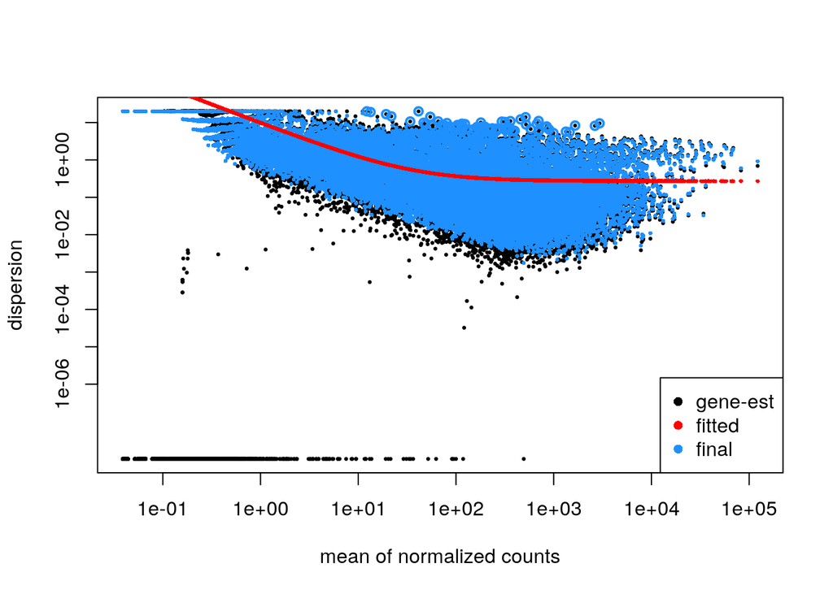

```r
plotDispEsts(dds)
```

Check the different contrasts

```r
resultsNames(dds)
```

```
## [1] "Intercept"                  "Flexure_T89_ROT_vs_T89_STA"
```

## 1.4 Results

The tissue type still has a too big effect on the DESeq to distinguish what exactly are the DE genes when only focusing on ROT and STA. Therefore we rerun the dds on the tissue specific data separately to take away the effect the tissue type has.

```r
ddsp <- dds[, dds$Tissue == "Phloem"]
ddsx <- dds[, dds$Tissue == "Xylem"]

vsdp <- varianceStabilizingTransformation(ddsp, blind = FALSE)
vstp <- assay(vsdp)
vstp <- vstp - min(vstp)
vsdx <- varianceStabilizingTransformation(ddsx, blind = FALSE)
vstx <- assay(vsdx)
vstx <- vstx - min(vstx)
```

## 1.5 Differential Expression

```r
ddsp <- DESeq(ddsp)
```

```
## found already estimated dispersions, replacing these
```

```r
ddsx <- DESeq(ddsx)
```

```
## found already estimated dispersions, replacing these
```

- Dispersion estimation The dispersion estimation is adequate

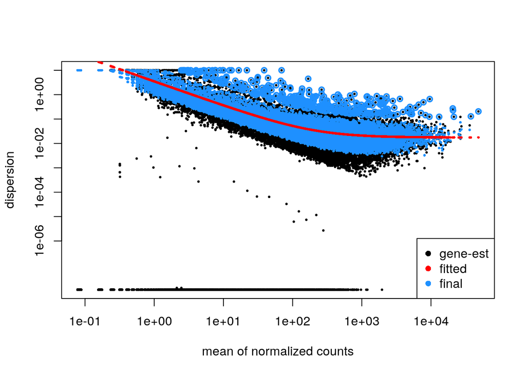

```r
plotDispEsts(ddsp)
```

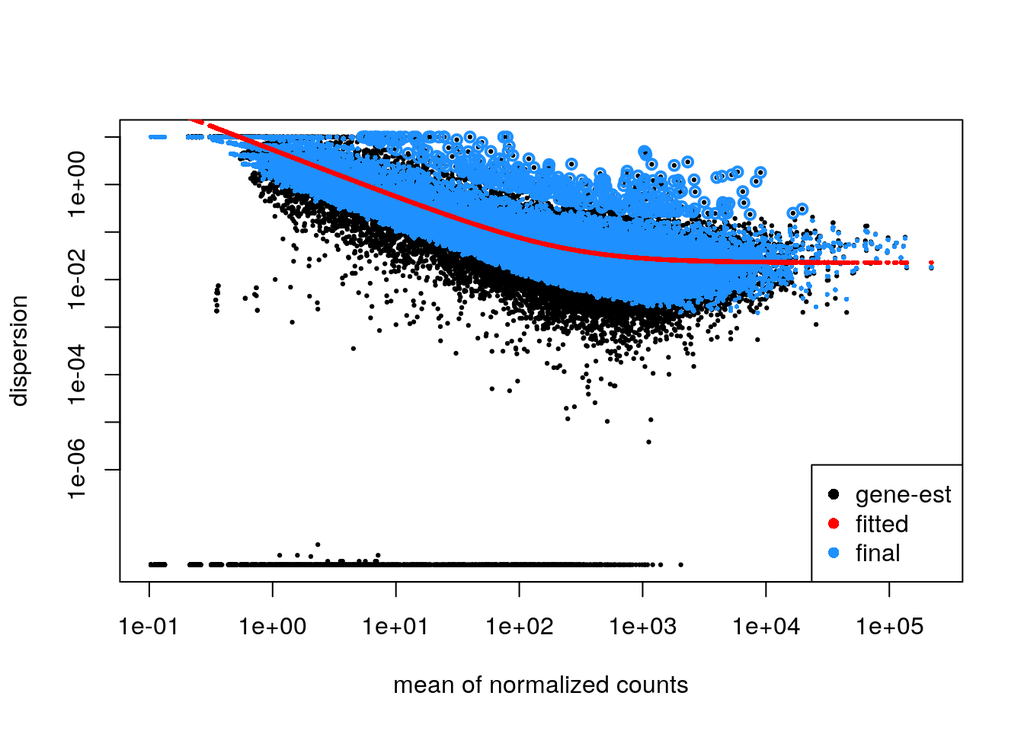

```r
plotDispEsts(ddsx)
```

Check the different contrasts

```r
resultsNames(ddsp)
```

```
## [1] "Intercept"                  "Flexure_T89_ROT_vs_T89_STA"
```

```r
resultsNames(ddsx)
```

```
## [1] "Intercept"                  "Flexure_T89_ROT_vs_T89_STA"
```

```r
contrast1pL <- extract_results(dds = ddsp, vst = vstp, contrast = "Flexure_T89_ROT_vs_T89_STA",
                               annot = Potra_blast2go, default_dir = here("export"), default_prefix = "phloem_DEGs_")
```

```
## Using the median normalized counts as default, set filter=NULL to revert to using the mean
```

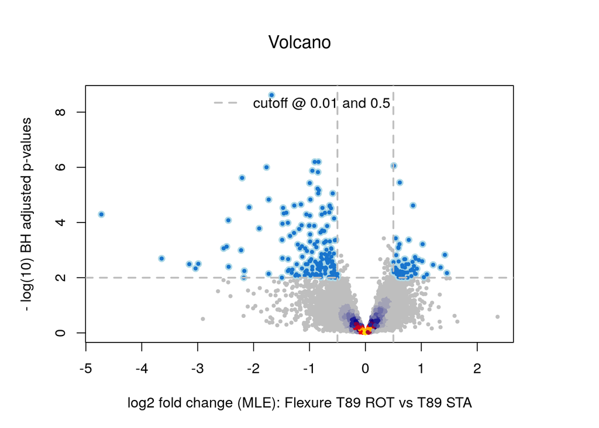

```
## The independent filtering cutoff is 13.67137, removing 44.0867% of the data
```

```
## The independent filtering maximises for 47.81206 % of the data, corresponding to a base mean expression of 29.64544 (library-size normalised read)
```

```
## There are 222 genes that are DE with the following parameters: FDR <= 0.01, |log2FC| >= 0.5, base mean expression > 0
```

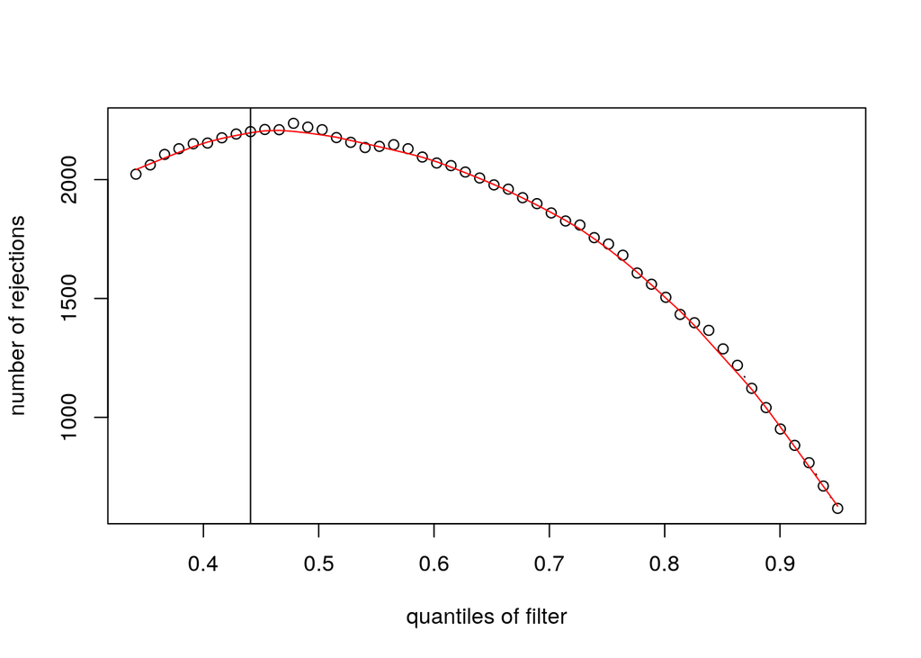

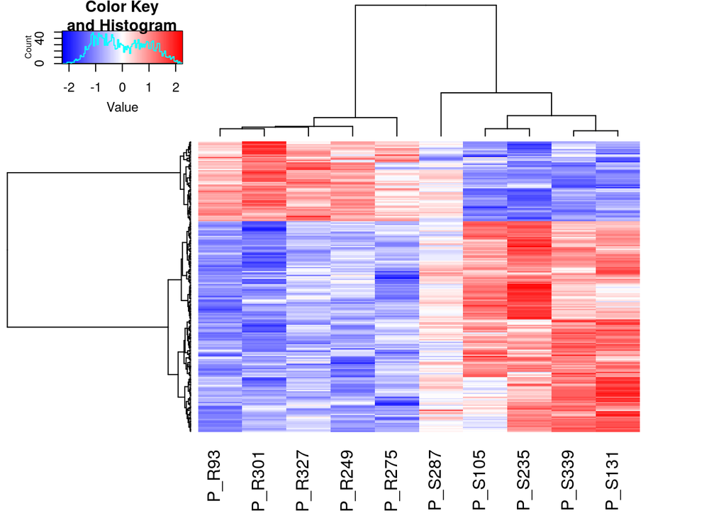

```r
contrast1xL <- extract_results(dds = ddsx, vst = vstx, contrast = "Flexure_T89_ROT_vs_T89_STA",
                               annot = Potra_blast2go, default_dir = here("export"), default_prefix = "xylem_DEGs_")
```

```
## Using the median normalized counts as default, set filter=NULL to revert to using the mean
```

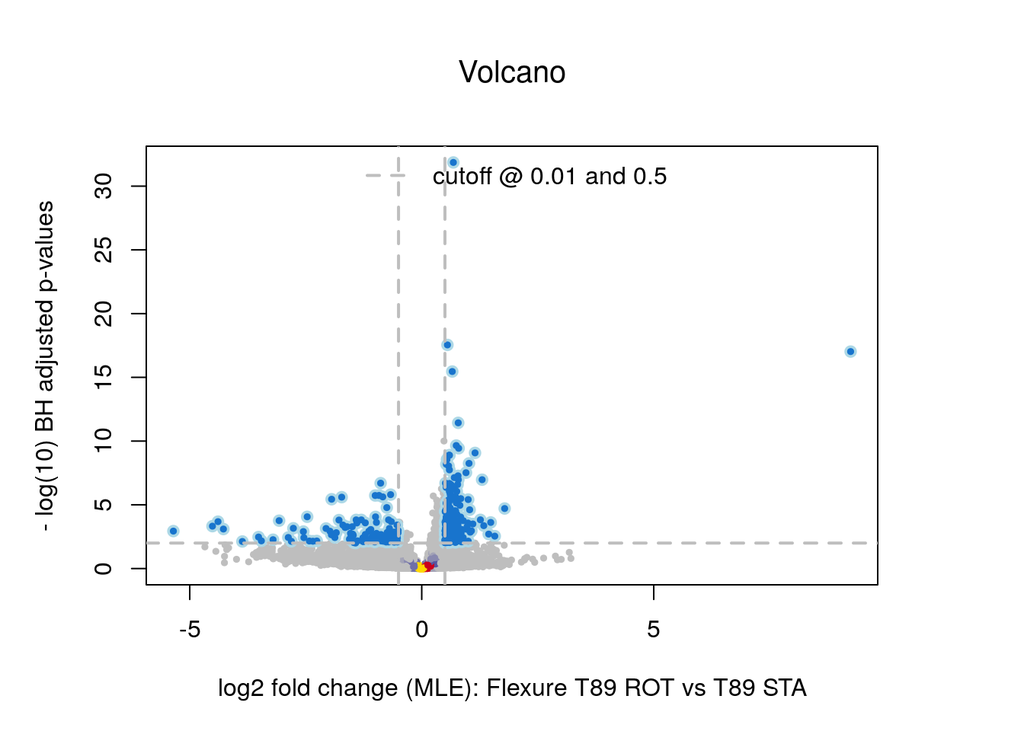

```
## The independent filtering cutoff is 1.73917, removing 40.16483% of the data
```

```
## The independent filtering maximises for 42.49825 % of the data, corresponding to a base mean expression of 4.50872 (library-size normalised read)
```

```
## There are 361 genes that are DE with the following parameters: FDR <= 0.01, |log2FC| >= 0.5, base mean expression > 0
```

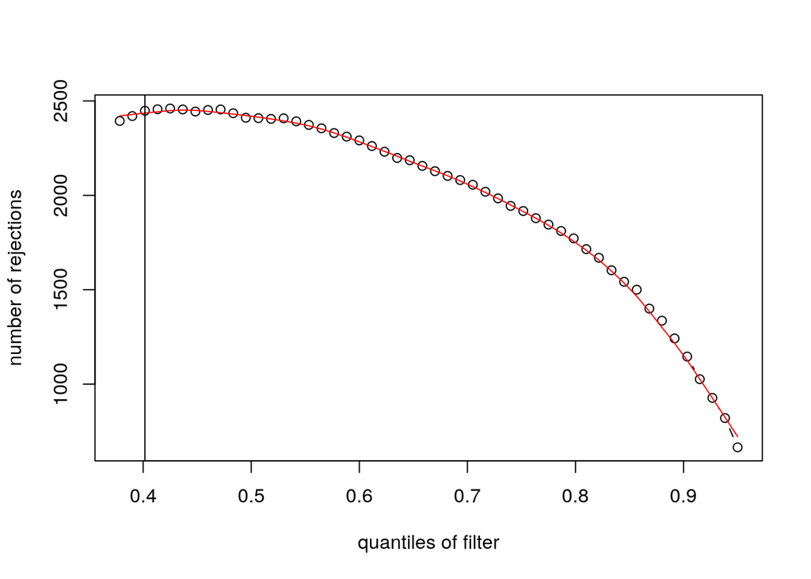

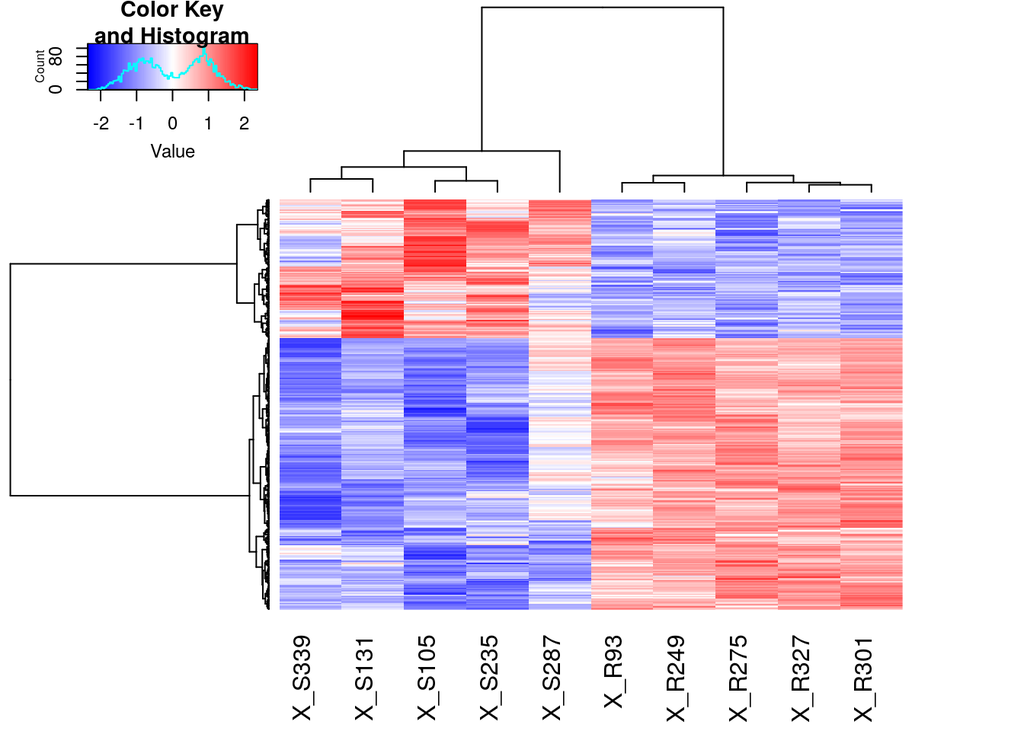

### 1.5.1 Venn Diagram

Assessing overlap of DEGs between tissues. 32 genes overlap between the two different tissue types.

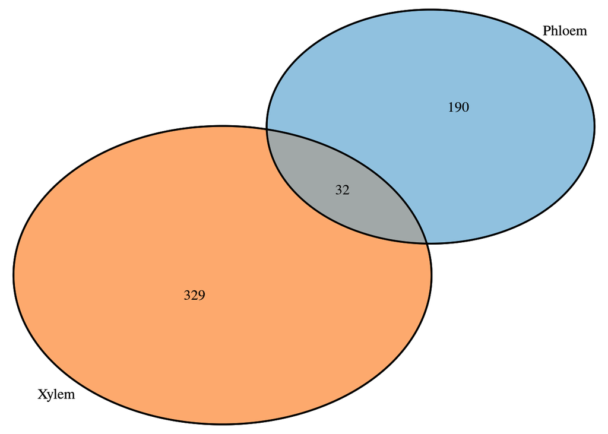

```r
grid.newpage()
grid.draw(draw.pairwise.venn(area1 = length(contrast1pL$all), area2 = length(contrast1xL$all),
                             cross.area = length(intersect(contrast1pL$all, contrast1xL$all)), category = c("Phloem", "Xylem"),
                             fill = c("#6baed6", "#fd8d3c"), cat.pos = c(45, 225), euler.d = TRUE, sep.dist = 0.09,
                             rotation.degree = 45, filename = NULL
))
```